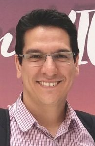

# Daniel Umpierre

## Olá,

Sou professor adjunto de Saúde Coletiva na Universidade Federal do Rio Grande do Sul (UFRGS), em Porto Alegre (RS). De forma ampla, meus interesses de pesquisa incluem avaliação de tecnologias em saúde (especialmente intervenções não-farmacológicas) e síntese de evidências. Meu grupo de pesquisa tem desenvolvido estudos metodológicos, revisões sistemáticas, e ensaios clínicos. Em todos os nossos projetos, temos buscando cada vez mais exercer práticas para uma ciência aberta, inclusiva, e centrada no público.

## Bio

Sou formado em Educação Física, e desde cedo me interessei em exercício físico no contexto da saúde (ou exercício na saúde e na doença). Tive colegas, professores, e orientadores exemplares, os quais foram, muitos ainda são, essenciais na minha formação como pessoa e pesquisador. Meus interesses acadêmicos durante o mestrado e doutorado se basearam em fisiopatologia do exercício físico, e no pós-doutorado expandi minha atuação em métodos de síntese de evidência. Tais ênfases hoje contribuem para minha linha de pesquisa, a qual abrange dois domínios: (1) intervenções de atividade física em indivíduos em risco de saúde ou acometidos por doenças (geralmente, doenças crônicas), através da realização de estudos primários (ensaios clínicos) ou revisões sistemáticas; (2) meta-pesquisa em ciências do exercício, o que foi iniciado através da observação de práticas inconsistentes ou não-recomendadas na minha área de atuação, incluindo diversas práticas inadequadas em manuscritos de minha autoria.

Na graduação, sou professor do Bacharelado em Saúde Coletiva (UFRGS) e leciono: (i) vigilância epidemiológica, (ii) metodologia da pesquisa e bioestatística, e (iii) saúde do idoso. Na pós-graduação, desde 2013, sou orientador permanente do Programa de Pós-Graduação em Cardiologia e Ciências Cardiovasculares/UFRGS e, mais recentemente (desde 2017), do PPG Saúde Coletiva/UFRGS.

Me envolvo ativamente nos projetos e com as pessoas com quem trabalho. Oriento estudantes e supervisiono postdocs com foco em excelência técnica/metodológica e formação da carreira docente. Para isso, promovo continuamente uma postura científica e ética, pois é isso que deve estar primariamente refletido em nossa pesquisa.

## Education

**Federal University of Rio Grande do Sul** | Porto Alegre, RS, Brazil

PhD in Health Sciences (Cardiovascular Sciences) | March 2008 - March 2012

**Federal University of Rio Grande do Sul** | Porto Alegre, RS, Brazil

MSc in Health Sciences (Cardiovascular Sciences) | March 2006 - December 2007

**Federal University of Rio Grande do Sul** | Porto Alegre, RS, Brazil

B.S. in Exercise Sciences (Kinesiology) | March 2001 - March 2005

## Experience

**Federal University of Rio Grande do Sul** | Assistant Professor | April 2017 - Present

**Federal University of Pelotas** | Assistant Professor | February 2016 - April 2017

**Institute of Health Technology Assessment** | Postdoctoral fellow | October 2012 - December 2015